# Final Project analysis

```python
import os
os.getcwd()
```

```
'C:\\Users\\Precious Olalere\\Documents\\IS 567 Text Mining'
```

```python
import pandas as pd
```

```python
mental_con = pd.read_csv("mental_train.csv")

mental_con.head(10)
```

|  | Context | Response |
| --- | --- | --- |
| 0 | I'm going through some things with my feelings and myself. I barely sleep and I do nothing but think about how I'm worthless and how I shouldn't be here.\n I've never tried or contemplated suicide. I'… | If everyone thinks you're worthless, then maybe you need to find new people to hang out with.Seriously, the social context in which a person lives is a big influence in self-esteem.Otherwise, you can … |
| 1 | I'm going through some things with my feelings and myself. I barely sleep and I do nothing but think about how I'm worthless and how I shouldn't be here.\n I've never tried or contemplated suicide. I'… | Hello, and thank you for your question and seeking advice on this. Feelings of worthlessness is unfortunately common. In fact, most people, if not all, have felt this to some degree at some point in t… |
| 2 | I'm going through some things with my feelings and myself. I barely sleep and I do nothing but think about how I'm worthless and how I shouldn't be here.\n I've never tried or contemplated suicide. I'… | First thing I'd suggest is getting the sleep you need or it will impact how you think and feel. I'd look at finding what is going well in your life and what you can be grateful for. I believe everyone… |
| 3 | I'm going through some things with my feelings and myself. I barely sleep and I do nothing but think about how I'm worthless and how I shouldn't be here.\n I've never tried or contemplated suicide. I'… | Therapy is essential for those that are feeling depressed and worthless. When I work with those that are experiencing concerns related to feeling of depression and issues with self esteem. I generally… |
| 4 | I'm going through some things with my feelings and myself. I barely sleep and I do nothing but think about how I'm worthless and how I shouldn't be here.\n I've never tried or contemplated suicide. I'… | I first want to let you know that you are not alone in your feelings and there is always someone there to help. You can always change your feelings and change your way of thinking by being open to try… |
| 5 | I'm going through some things with my feelings and myself. I barely sleep and I do nothing but think about how I'm worthless and how I shouldn't be here.\n I've never tried or contemplated suicide. I'… | Heck, sure thing, hun!Feelings of 'depression' have a deeply-rooted base in physical structures that may not be functioning very well at present; and, we can certainly turn them on again using means t… |
| 6 | I'm going through some things with my feelings and myself. I barely sleep and I do nothing but think about how I'm worthless and how I shouldn't be here.\n I've never tried or contemplated suicide. I'… | You are exhibiting some specific traits of a particular temperament type. Seek out a counselor who provides NCCA temperament therapy and discover the joy of being you -- God loves you as you are! |
| 7 | I'm going through some things with my feelings and myself. I barely sleep and I do nothing but think about how I'm worthless and how I shouldn't be here.\n I've never tried or contemplated suicide. I'… | That is intense. Depression is a liar. Sometimes depression places these glasses over our eyes, these dark sunglasses that change how we see things. Depression tells us things like "you're worthless" … |
| 8 | I'm going through some things with my feelings and myself. I barely sleep and I do nothing but think about how I'm worthless and how I shouldn't be here.\n I've never tried or contemplated suicide. I'… | It sounds like you may be putting yourself last. You wrote that you want to fix your issues but never get around to it. I wonder how you are spending your mental and physical energy. Are you spending … |
| 9 | I'm going through some things with my feelings and myself. I barely sleep and I do nothing but think about how I'm worthless and how I shouldn't be here.\n I've never tried or contemplated suicide. I'… | It must be really difficult to experience what your going through right now. It takes a lot of courage to reach out. It sounds like you want to get better, but perhaps need some help to get over the h… |

```python
# Setting a specific maximum column width
pd.set_option('display.max_colwidth', 50)

# Displaying the first 10 rows of the DataFrame
mental_con.head(10)
```

|  | Context | Response |
| --- | --- | --- |
| 0 | I'm going through some things with my feelings... | If everyone thinks you're worthless, then mayb... |
| 1 | I'm going through some things with my feelings... | Hello, and thank you for your question and see... |
| 2 | I'm going through some things with my feelings... | First thing I'd suggest is getting the sleep y... |
| 3 | I'm going through some things with my feelings... | Therapy is essential for those that are feelin... |
| 4 | I'm going through some things with my feelings... | I first want to let you know that you are not ... |
| 5 | I'm going through some things with my feelings... | Heck, sure thing, hun!Feelings of 'depression'... |
| 6 | I'm going through some things with my feelings... | You are exhibiting some specific traits of a p... |
| 7 | I'm going through some things with my feelings... | That is intense. Depression is a liar. Sometim... |
| 8 | I'm going through some things with my feelings... | It sounds like you may be putting yourself las... |
| 9 | I'm going through some things with my feelings... | It must be really difficult to experience what... |

```python
mental_con.shape
```

```
(3512, 2)
```

```python
mental_con.dtypes
```

```
Context     object
Response    object
dtype: object
```

```python
#Check for Missing Values

mental_con.isnull().sum()
```

```
Context     0
Response    4
dtype: int64
```

```python
#dropping nan values in response column
#news.drop(news[news.text.isnull()].index, axis=0).head(10)
# Drop rows where 'text' column has NaN values
mental_con = mental_con.dropna(subset=['Response'])

# Display the first 10 rows after dropping NaN values
mental_con.isnull().sum()
```

```
Context     0
Response    0
dtype: int64
```

```python
mental_con.shape
```

```
(3508, 2)
```

# Performing Analysis on the Context Column which is the patients entry in order to answer research question 1; What are the most frequent topics or challenges faced by people with mental health issues?

```python
#Converting all text from the “Context” column to lowercase.
mental_con["Context"] = mental_con["Context"].str.lower()
mental_con["Context"].head(5)
```

```
0    i'm going through some things with my feelings...
1    i'm going through some things with my feelings...
2    i'm going through some things with my feelings...
3    i'm going through some things with my feelings...
4    i'm going through some things with my feelings...
Name: Context, dtype: object
```

```python
#Removing non-alphanumeric characters that appear in Context (e.g. ‘<’, ‘>’, ‘*’, ‘+’.).
#Convert all text to lowercase. Create a new column “cleaned_Context” to contain the extracted output

import re

mental_con["Cleaned_Context"] = mental_con["Context"].str.lower().str.replace(r'[^a-zA-Z0-9\s]', '', regex=True)
mental_con[["Context", "Cleaned_Context"]].head(10)
```

|  | Context | Cleaned_Context |
| --- | --- | --- |
| 0 | i'm going through some things with my feelings... | im going through some things with my feelings ... |
| 1 | i'm going through some things with my feelings... | im going through some things with my feelings ... |
| 2 | i'm going through some things with my feelings... | im going through some things with my feelings ... |
| 3 | i'm going through some things with my feelings... | im going through some things with my feelings ... |
| 4 | i'm going through some things with my feelings... | im going through some things with my feelings ... |
| 5 | i'm going through some things with my feelings... | im going through some things with my feelings ... |
| 6 | i'm going through some things with my feelings... | im going through some things with my feelings ... |
| 7 | i'm going through some things with my feelings... | im going through some things with my feelings ... |
| 8 | i'm going through some things with my feelings... | im going through some things with my feelings ... |
| 9 | i'm going through some things with my feelings... | im going through some things with my feelings ... |

```python
#Using NLTK to tokenize the context text (Context & cleaned_Context column).
#nltk.download('punkt')
from nltk.tokenize import word_tokenize
mental_con["Tokenized_Cleaned_Context"] = mental_con["Cleaned_Context"].apply(word_tokenize)
mental_con[["Cleaned_Context","Tokenized_Cleaned_Context" ]].head(10)
```

|  | Cleaned_Context | Tokenized_Cleaned_Context |
| --- | --- | --- |
| 0 | im going through some things with my feelings ... | [im, going, through, some, things, with, my, f... |
| 1 | im going through some things with my feelings ... | [im, going, through, some, things, with, my, f... |
| 2 | im going through some things with my feelings ... | [im, going, through, some, things, with, my, f... |
| 3 | im going through some things with my feelings ... | [im, going, through, some, things, with, my, f... |
| 4 | im going through some things with my feelings ... | [im, going, through, some, things, with, my, f... |
| 5 | im going through some things with my feelings ... | [im, going, through, some, things, with, my, f... |
| 6 | im going through some things with my feelings ... | [im, going, through, some, things, with, my, f... |
| 7 | im going through some things with my feelings ... | [im, going, through, some, things, with, my, f... |
| 8 | im going through some things with my feelings ... | [im, going, through, some, things, with, my, f... |
| 9 | im going through some things with my feelings ... | [im, going, through, some, things, with, my, f... |

```python
#removing stop words
from nltk.corpus import stopwords

stop_words = set(stopwords.words("english"))
def remove_stopwords(tokenized_text):
    return [word for word in tokenized_text if word not in stop_words]

mental_con["Stopword_Removed_Context"] = mental_con["Tokenized_Cleaned_Context"].apply(remove_stopwords)
mental_con[["Tokenized_Cleaned_Context", "Stopword_Removed_Context"]].head(10)
```

|  | Tokenized_Cleaned_Context | Stopword_Removed_Context |
| --- | --- | --- |
| 0 | [im, going, through, some, things, with, my, f... | [im, going, things, feelings, barely, sleep, n... |
| 1 | [im, going, through, some, things, with, my, f... | [im, going, things, feelings, barely, sleep, n... |
| 2 | [im, going, through, some, things, with, my, f... | [im, going, things, feelings, barely, sleep, n... |
| 3 | [im, going, through, some, things, with, my, f... | [im, going, things, feelings, barely, sleep, n... |
| 4 | [im, going, through, some, things, with, my, f... | [im, going, things, feelings, barely, sleep, n... |
| 5 | [im, going, through, some, things, with, my, f... | [im, going, things, feelings, barely, sleep, n... |
| 6 | [im, going, through, some, things, with, my, f... | [im, going, things, feelings, barely, sleep, n... |
| 7 | [im, going, through, some, things, with, my, f... | [im, going, things, feelings, barely, sleep, n... |
| 8 | [im, going, through, some, things, with, my, f... | [im, going, things, feelings, barely, sleep, n... |
| 9 | [im, going, through, some, things, with, my, f... | [im, going, things, feelings, barely, sleep, n... |

```python
import gensim
from gensim import corpora
import operator

import numpy as np
import random
```

```python
#Convert the “context” column into a bag-of-words representation using gensim's corpora.dictionary methods.
#Restrict vocabulary to only the top 10K terms that show up in at least 5 documents and no more than 20% of all documents.

# Create a dictionary from the processed text
dictionary = corpora.Dictionary(mental_con["Stopword_Removed_Context"])
dictionary.filter_extremes(no_below=5, no_above=.2, keep_n=10000)

corpus = [dictionary.doc2bow(text) for text in mental_con["Stopword_Removed_Context"]]
num_topics=8
```

```python
#Run topic modeling on this data using gensim's built-in LDA.
#Target 8 topics.
#Print top 20 words under each topic.

lda_model = gensim.models.ldamodel.LdaModel(corpus=corpus,
                                           id2word=dictionary,
                                           num_topics=num_topics,
                                           passes=10,
                                           alpha='auto')
```

```python
for i in range(num_topics):
    print("topic %s:\t%s" % (i, ' '.join([term for term, freq in lda_model.show_topic(i, topn=20)])))
```

```
topic 0:	something therapist would fear never need start right always even really feeling better problem ill wrong cry give way people
topic 1:	time even years sometimes every never sex everything think family past makes friends see going ive cant love doesnt want
topic 2:	still feeling normal therapy ive want someone child people gone relationship thoughts nervous walk things far couple everytime shaky sessions
topic 3:	sex want years boyfriend anxiety family think found lot cant stop away people together back time school job cheated times
topic 4:	ive issues many counseling history address never years depression anxiety almost abuse married cancer sexual self low survivor long beginning
topic 5:	counseling help really end counselor time working client decide much anything life relationship person someone started always go sessions process
topic 6:	want years life mother relationship really told mom think live never wife time ive one would sex dad child love
topic 7:	cant ive always talk love hes want really friends still time one doesnt help trust things never even parents make
```

```python
#Sample Analysis for the 8 topics generated
#Create a new column “Dominant_Topic” to contain the dominant topic and a new column “Topic_Perc_contrib”
#to contain dominant topic percentage contribution results.

import pandas as pd

# Function to find the dominant topic and its percentage contribution
def find_dominant_topic(ldamodel, corpus):
    dominant_topic_list = []
    topic_percentage_list = []

    for i, doc_bow in enumerate(corpus):
        # Get the topic distribution for the document
        topics_per_document = ldamodel.get_document_topics(doc_bow, minimum_probability=0)

        # Sort the topics by contribution (in descending order) and get the top one
        dominant_topic, topic_perc_contrib = max(topics_per_document, key=lambda x: x[1])

        # Append dominant topic and its percentage contribution to respective lists
        dominant_topic_list.append(dominant_topic)
        topic_percentage_list.append(topic_perc_contrib)

    return dominant_topic_list, topic_percentage_list

# Call the function to get dominant topics and percentage contributions
dominant_topics, topic_perc_contrib = find_dominant_topic(lda_model, corpus)

# Add the new columns to mental_con dataframe
mental_con['Dominant_Topic'] = dominant_topics
mental_con['Topic_Perc_contrib'] = topic_perc_contrib

# Display the first few rows with the new columns
mental_con[['Dominant_Topic', 'Topic_Perc_contrib', 'Context']].head()
```

|  | Dominant_Topic | Topic_Perc_contrib | Context |
| --- | --- | --- | --- |
| 0 | 3 | 0.992729 | i'm going through some things with my feelings... |
| 1 | 3 | 0.992729 | i'm going through some things with my feelings... |
| 2 | 3 | 0.992729 | i'm going through some things with my feelings... |
| 3 | 3 | 0.992729 | i'm going through some things with my feelings... |
| 4 | 3 | 0.992729 | i'm going through some things with my feelings... |

```python
#Retrieve and display the document text with the highest topic percentage contribution (Topic_Perc_Contrib in the screenshot) for each 8 topics.
#If the document text is too long, print the first 800 characters of the text.
#For each document, print the dominant topic assigned by LDA
# Define the number of topics to retrieve
num_topics = 8

# Loop over each topic and find the document with the highest percentage contribution
for topic in range(num_topics):
    topic_df = mental_con[mental_con['Dominant_Topic'] == topic]
    max_contrib_row = topic_df.loc[topic_df['Topic_Perc_contrib'].idxmax()]
    document_text = max_contrib_row['Context'][:800]


    print(f"Topic: {topic}")
    print(f"Dominant Topic Contribution: {max_contrib_row['Topic_Perc_contrib']:.4f}")
    print(f"Document Context (First 800 characters):\n{document_text}")
    print("-" * 100)
```

```
Topic: 0
Dominant Topic Contribution: 0.9923
Document Context (First 800 characters):
my therapist is gay so there are no sexual issues here. however, my therapist for six years has made me believe that he cares about me and that we are friends. i have loaned money to him many times, and he always paid me back.
   i had a medical emergency last weekend and i was heavily medicated. i knew that this therapist came into my home and wrote down my credit card information so he could pay back what he owed me, but this therapist dropped me off and never came again. i don't know what to do.
----------------------------------------------------------------------------------------------------
Topic: 1
Dominant Topic Contribution: 0.9952
Document Context (First 800 characters):
my wife and i have a great relationship except for our sex lives. we are pretty transparent and honest, and basically, she feels bad because she never wants to have sex. she doesn't have the desire. she's also never orgasmed. she feels like a terrible wife and fears i'll cheat on her. she doesn't kn…
----------------------------------------------------------------------------------------------------
Topic: 2
Dominant Topic Contribution: 0.9937
Document Context (First 800 characters):
whenever i run into a situation that makes me upset or angry, i tend to start cursing and badly offending the person i am confronting. i say mean things to let my anger out. whenever people tell me stuff about my relationship (like starting rumors or saying negative things about me or my relationshi…
----------------------------------------------------------------------------------------------------
Topic: 3
Dominant Topic Contribution: 0.9970
Document Context (First 800 characters):
i have lately been having lots of anxiety and self-loathing about the fact that i am a young adult virgin girl who has never had a boyfriend before. it seems like everyone my age has already had boyfriends by now or are not virgins anymore, and i just had my first kiss five months ago. i’m worried t…
----------------------------------------------------------------------------------------------------
Topic: 4
Dominant Topic Contribution: 0.9971
Document Context (First 800 characters):
my husband has had issues with alcohol addiction in the past (he'd never admit to this). a while back (3 years ago), i asked him to stop drinking so much, and he agreed. i caught him one night drinking behind my back. i confronted him and he lied, but i told him i knew he was lying because i counted…
 the other night, i counted the beers in the fridge just to see if some were missing. it took a couple of days, but tonight, i discov
----------------------------------------------------------------------------------------------------
Topic: 5
Dominant Topic Contribution: 0.9962
Document Context (First 800 characters):
i'm a male in my 20s. my girlfriend is in her late 30s. she's great. she's funny and smart, she has a big heart, and we have an excellent sex life. she recently moved in with me partially because she wanted to and partially because she had no place to go. we fight a lot. it’s mostly my fault, i must…
----------------------------------------------------------------------------------------------------
Topic: 6
Dominant Topic Contribution: 0.9954
Document Context (First 800 characters):
my husband and i would've been married for five years come june 2016. our infant daughter just had her birthday. shortly before, he told me he wanted a divorce. he has four other children, three of which are from his first wife. he decided to end that marriage when his youngest was an infant. the ch…
----------------------------------------------------------------------------------------------------
Topic: 7
Dominant Topic Contribution: 0.9972
Document Context (First 800 characters):
i am constantly having problems with the same two people who will always be in my life. i had a daughter with my ex-boyfriend. i am now married, and my husband’s ex-girlfriend is involved with my ex-boyfriend. they also have a daughter together. my issue is that there is always drama. i am pregnant,…
----------------------------------------------------------------------------------------------------
```

```python
#Analyze LDA model results.
#Visualize the topics for interpretation. Use pyLDAvis, a visualization package, to interpret individual topics
#and the relationships between the topics

import pyLDAvis.gensim_models as gensimvis
import pyLDAvis

# Prepare the visualization
lda_display = gensimvis.prepare(lda_model, corpus, dictionary)

# Display the visualization
pyLDAvis.display(lda_display)
```

[interactive chart not shown]

```python
pyLDAvis.save_html(lda_display, '8topic lda viz.html')
```

```python
#Changing the number of topics (e.g., 4) and compare the results.
corpus = [dictionary.doc2bow(text) for text in mental_con["Stopword_Removed_Context"]]
num_topics=4
```

```python
lda_model = gensim.models.ldamodel.LdaModel(corpus=corpus,
                                           id2word=dictionary,
                                           num_topics=num_topics,
                                           passes=10,
                                           alpha='auto')
```

```python
for i in range(num_topics):
    print("topic %s:\t%s" % (i, ' '.join([term for term, freq in lda_model.show_topic(i, topn=20)])))
```

```
topic 0:	want years time love always really think never husband going sex see someone much doesnt told ive help even relationship
topic 1:	counseling ive anxiety many never issues history address years depression really sexual anything married almost time abuse people self survivor
topic 2:	ive still relationship always cant normal want family sessions people therapy parents never nervous make talk feeling boyfriend back things
topic 3:	want would ive time things feeling something relationship start even past person really therapist think life never friends sex cant
```

```python
# Prepare the visualization
lda_display = gensimvis.prepare(lda_model, corpus, dictionary)

# Display the visualization
pyLDAvis.display(lda_display)
```

[interactive chart not shown]

The first cluster had so many overlaps so I had to reduce it to 4 topics. this worked better and was quite distinct. For the presentation I can talk about what each topics represents in terms of their themes and words included in them.

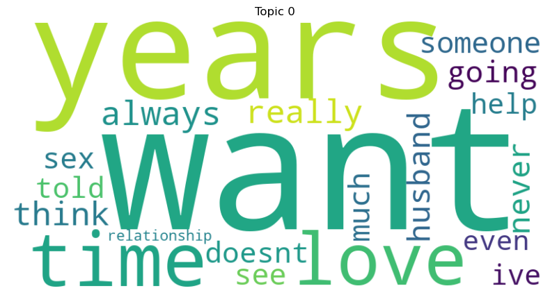

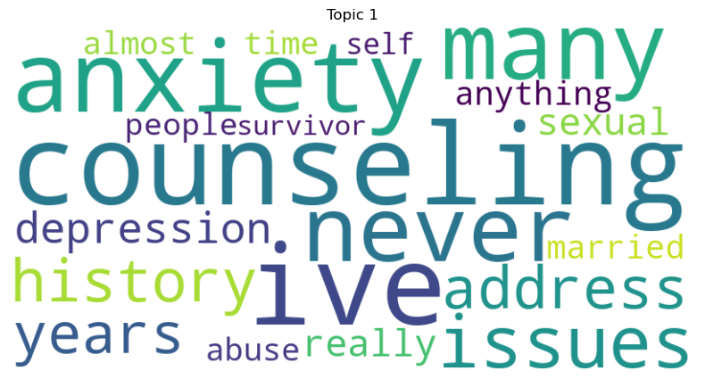

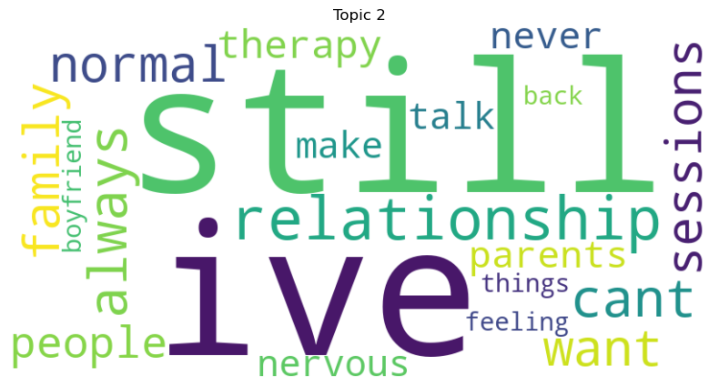

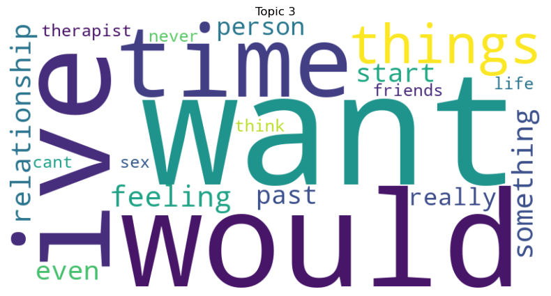

```python
import matplotlib.pyplot as plt
from wordcloud import WordCloud

# Loop through the topics
for i in range(num_topics):
    # Get the top 20 terms for each topic
    terms_freq = lda_model.show_topic(i, topn=20)

    # Convert the terms and frequencies into a dictionary
    terms_dict = {term: freq for term, freq in terms_freq}

    # Create a WordCloud object
    wordcloud = WordCloud(width=800, height=400, background_color='white').generate_from_frequencies(terms_dict)

    # Display the word cloud for each topic
    plt.figure(figsize=(10, 5))
    plt.imshow(wordcloud, interpolation='bilinear')
    plt.axis('off')
    plt.title(f"Topic {i}")
    plt.show()
```

```python
#Task: Sample Analysis for 4 topics generated.
#Create a new column “Dominant_Topic” to contain the dominant topic and a new column “Topic_Perc_contrib”
#to contain dominant topic percentage contribution results.

import pandas as pd

# Function to find the dominant topic and its percentage contribution
def find_dominant_topic(ldamodel, corpus):
    dominant_topic_list = []
    topic_percentage_list = []

    for i, doc_bow in enumerate(corpus):
        # Get the topic distribution for the document
        topics_per_document = ldamodel.get_document_topics(doc_bow, minimum_probability=0)

        # Sort the topics by contribution (in descending order) and get the top one
        dominant_topic, topic_perc_contrib = max(topics_per_document, key=lambda x: x[1])

        # Append dominant topic and its percentage contribution to respective lists
        dominant_topic_list.append(dominant_topic)
        topic_percentage_list.append(topic_perc_contrib)

    return dominant_topic_list, topic_percentage_list

# Call the function to get dominant topics and percentage contributions
dominant_topics, topic_perc_contrib = find_dominant_topic(lda_model, corpus)

# Add the new columns to the mental_con dataframe
mental_con['Dominant_Topic'] = dominant_topics
mental_con['Topic_Perc_contrib'] = topic_perc_contrib

# Display the first few rows with the new columns
mental_con[['Dominant_Topic', 'Topic_Perc_contrib', 'Context']].head()
```

|  | Dominant_Topic | Topic_Perc_contrib | Context |
| --- | --- | --- | --- |
| 0 | 3 | 0.992729 | i'm going through some things with my feelings... |
| 1 | 3 | 0.992729 | i'm going through some things with my feelings... |
| 2 | 3 | 0.992729 | i'm going through some things with my feelings... |
| 3 | 3 | 0.992729 | i'm going through some things with my feelings... |
| 4 | 3 | 0.992729 | i'm going through some things with my feelings... |

```python
#Retrieve and display the document text with the highest topic percentage contribution (Topic_Perc_Contrib in the screenshot) for each 8 topics.
#If the document text is too long, print the first 800 characters of the text.
#For each document, print the dominant topic assigned by LDA
# Define the number of topics to retrieve
num_topics = 4

# Loop over each topic and find the document with the highest percentage contribution
for topic in range(num_topics):
    topic_df = mental_con[mental_con['Dominant_Topic'] == topic]
    max_contrib_row = topic_df.loc[topic_df['Topic_Perc_contrib'].idxmax()]
    document_text = max_contrib_row['Context'][:800]


    print(f"Topic: {topic}")
    print(f"Dominant Topic Contribution: {max_contrib_row['Topic_Perc_contrib']:.4f}")
    print(f"Document Context (First 800 characters):\n{document_text}")
    print("-" * 100)
```

```
Topic: 0
Dominant Topic Contribution: 0.9985
Document Context (First 800 characters):
my husband has had issues with alcohol addiction in the past (he'd never admit to this). a while back (3 years ago), i asked him to stop drinking so much, and he agreed. i caught him one night drinking behind my back. i confronted him and he lied, but i told him i knew he was lying because i counted…
 the other night, i counted the beers in the fridge just to see if some were missing. it took a couple of days, but tonight, i discov
----------------------------------------------------------------------------------------------------
Topic: 1
Dominant Topic Contribution: 0.9946
Document Context (First 800 characters):
sometimes i can't stop thinking about life after death. i was raised in a religion that teaches that we will live on forever either in hell or in heaven.  when i think of living forever (even if it is in heaven which should be good), i feel overwhelmed. i don't like the thought of living forever and…
----------------------------------------------------------------------------------------------------
Topic: 2
Dominant Topic Contribution: 0.9983
Document Context (First 800 characters):
i have lately been having lots of anxiety and self-loathing about the fact that i am a young adult virgin girl who has never had a boyfriend before. it seems like everyone my age has already had boyfriends by now or are not virgins anymore, and i just had my first kiss five months ago. i’m worried t…
----------------------------------------------------------------------------------------------------
Topic: 3
Dominant Topic Contribution: 0.9979
Document Context (First 800 characters):
i've worked with this guy for about three years now, and i knew the first time i saw him that i was attracted. over time, he became a very dear friend, and we talked about our relationship problems, family, dreams, and so on. there was always flirtation with us, and one day pretty recently, it progr…
   i'm trying so hard to maintain the friendship because that's what he wants. we're no longer in the same office, which i thought would help me get over these feelings, but we still talk about work, and he's constantly touching me, so i'm still very drawn to him. he's a hugger and such a sweet guy,…
----------------------------------------------------------------------------------------------------
```

# Performing Analysis on the Response Column which is the doctor entry in order to answer research question 2; What are the key mental health expressions or responses are often used by therapist treating individuals with mental health issues?

```python
#Converting all text from the “Response” column to lowercase.
mental_con["Response"] = mental_con["Response"].str.lower()
mental_con["Response"].head(5)
```

```
0    if everyone thinks you're worthless, then mayb...
1    hello, and thank you for your question and see...
2    first thing i'd suggest is getting the sleep y...
3    therapy is essential for those that are feelin...
4    i first want to let you know that you are not ...
Name: Response, dtype: object
```

```python
#Removing non-alphanumeric characters that appear in Response (e.g. ‘<’, ‘>’, ‘*’, ‘+’.).
#Convert all text to lowercase. Create a new column “cleaned_Response” to contain the extracted output

import re

mental_con["Cleaned_Response"] = mental_con["Response"].str.lower().str.replace(r'[^a-zA-Z0-9\s]', '', regex=True)
mental_con[["Response", "Cleaned_Response"]].head(10)
```

|  | Response | Cleaned_Response |
| --- | --- | --- |
| 0 | if everyone thinks you're worthless, then mayb... | if everyone thinks youre worthless then maybe ... |
| 1 | hello, and thank you for your question and see... | hello and thank you for your question and seek... |
| 2 | first thing i'd suggest is getting the sleep y... | first thing id suggest is getting the sleep yo... |
| 3 | therapy is essential for those that are feelin... | therapy is essential for those that are feelin... |
| 4 | i first want to let you know that you are not ... | i first want to let you know that you are not ... |
| 5 | heck, sure thing, hun!feelings of 'depression'... | heck sure thing hunfeelings of depression have... |
| 6 | you are exhibiting some specific traits of a p... | you are exhibiting some specific traits of a p... |
| 7 | that is intense. depression is a liar. sometim... | that is intense depression is a liar sometimes... |
| 8 | it sounds like you may be putting yourself las... | it sounds like you may be putting yourself las... |
| 9 | it must be really difficult to experience what... | it must be really difficult to experience what... |

```python
#Using NLTK to tokenize the Response text (Response & cleaned_Response column).
#nltk.download('punkt')
#from nltk.tokenize import word_tokenize
mental_con["Tokenized_Cleaned_Response"] = mental_con["Cleaned_Response"].apply(word_tokenize)
mental_con[["Cleaned_Response","Tokenized_Cleaned_Response" ]].head(10)
```

|  | Cleaned_Response | Tokenized_Cleaned_Response |
| --- | --- | --- |
| 0 | if everyone thinks youre worthless then maybe ... | [if, everyone, thinks, youre, worthless, then,... |
| 1 | hello and thank you for your question and seek... | [hello, and, thank, you, for, your, question, ... |
| 2 | first thing id suggest is getting the sleep yo... | [first, thing, id, suggest, is, getting, the, ... |
| 3 | therapy is essential for those that are feelin... | [therapy, is, essential, for, those, that, are... |
| 4 | i first want to let you know that you are not ... | [i, first, want, to, let, you, know, that, you... |
| 5 | heck sure thing hunfeelings of depression have... | [heck, sure, thing, hunfeelings, of, depressio... |
| 6 | you are exhibiting some specific traits of a p... | [you, are, exhibiting, some, specific, traits,... |
| 7 | that is intense depression is a liar sometimes... | [that, is, intense, depression, is, a, liar, s... |
| 8 | it sounds like you may be putting yourself las... | [it, sounds, like, you, may, be, putting, your... |
| 9 | it must be really difficult to experience what... | [it, must, be, really, difficult, to, experien... |

```python
#removing stop words
#from nltk.corpus import stopwords

stop_words = set(stopwords.words("english"))
def remove_stopwords(tokenized_text):
    return [word for word in tokenized_text if word not in stop_words]

mental_con["Stopword_Removed_Response"] = mental_con["Tokenized_Cleaned_Response"].apply(remove_stopwords)
mental_con[["Tokenized_Cleaned_Response", "Stopword_Removed_Response"]].head(10)
```

|  | Tokenized_Cleaned_Response | Stopword_Removed_Response |
| --- | --- | --- |
| 0 | [if, everyone, thinks, youre, worthless, then,... | [everyone, thinks, youre, worthless, maybe, ne... |
| 1 | [hello, and, thank, you, for, your, question, ... | [hello, thank, question, seeking, advice, feel... |
| 2 | [first, thing, id, suggest, is, getting, the, ... | [first, thing, id, suggest, getting, sleep, ne... |
| 3 | [therapy, is, essential, for, those, that, are... | [therapy, essential, feeling, depressed, worth... |
| 4 | [i, first, want, to, let, you, know, that, you... | [first, want, let, know, alone, feelings, alwa... |
| 5 | [heck, sure, thing, hunfeelings, of, depressio... | [heck, sure, thing, hunfeelings, depression, d... |
| 6 | [you, are, exhibiting, some, specific, traits,... | [exhibiting, specific, traits, particular, tem... |
| 7 | [that, is, intense, depression, is, a, liar, s... | [intense, depression, liar, sometimes, depress... |
| 8 | [it, sounds, like, you, may, be, putting, your... | [sounds, like, may, putting, last, wrote, want... |
| 9 | [it, must, be, really, difficult, to, experien... | [must, really, difficult, experience, going, r... |

```python
#Converting Token Lists to Strings
mental_con["Stopword_Removed_Response"] = mental_con["Stopword_Removed_Response"].apply(lambda tokens: ' '.join(tokens) if isinstance(tokens, list) else tokens)

mental_con["Stopword_Removed_Response"]. head (10) # Check the cleaned response
```

```
0    everyone thinks youre worthless maybe need fin...
1    hello thank question seeking advice feelings w...
2    first thing id suggest getting sleep need impa...
3    therapy essential feeling depressed worthless ...
4    first want let know alone feelings always some...
5    heck sure thing hunfeelings depression deeplyr...
6    exhibiting specific traits particular temperam...
7    intense depression liar sometimes depression p...
8    sounds like may putting last wrote want fix is...
9    must really difficult experience going right t...
Name: Stopword_Removed_Response, dtype: object
```

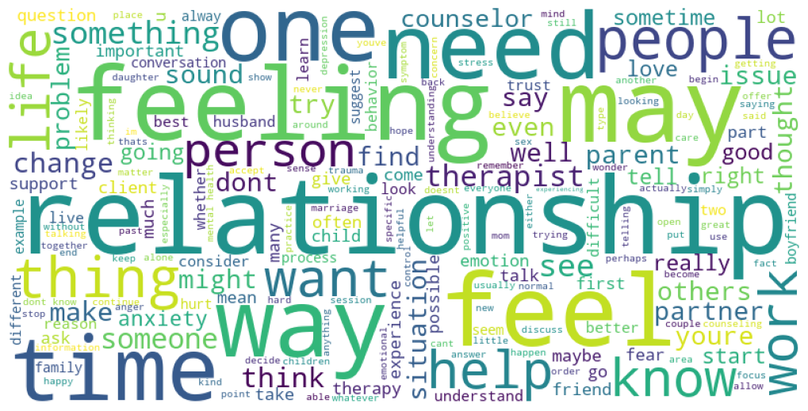

```python
#Topic modeling to get words to use for the labelling of the response column

#Generating a word cloud using "Stopword_Removed_Response" to get a visual representation of the most common words.

from wordcloud import WordCloud
import matplotlib.pyplot as plt

mental_text = " ".join(mental_con["Stopword_Removed_Response"])

# Generate the word cloud
wordcloud = WordCloud(width=800, height=400, background_color='white').generate(mental_text)

# Plot the word cloud using matplotlib
plt.figure(figsize=(10, 5))
plt.imshow(wordcloud)
plt.axis('off')  # Hide axes
plt.tight_layout(pad = 0)
plt.show()
```

```
Category
Both                    75.712657
Practical Steps         14.196123
Emotional Validation     6.613455
Neither                  3.477765
Name: proportion, dtype: float64
```

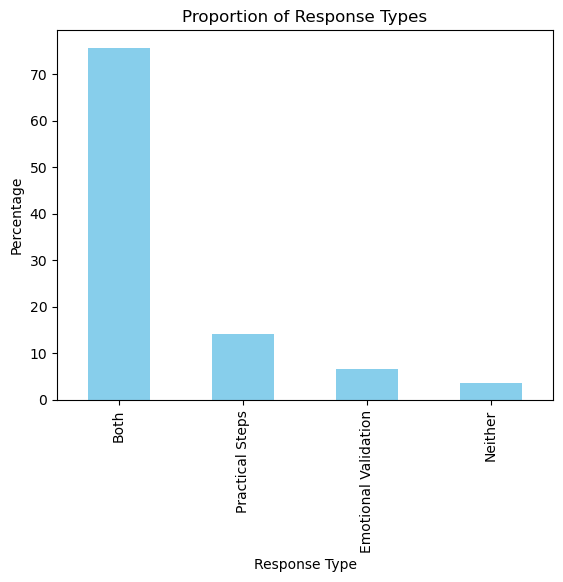

```python
#Using the words generated from the word cloud, I created keywords that we could use to label the respose column into practical steps,
#emotional validation, neither and both

# Define keywords for practical steps and emotional validation
practical_keywords = ["work on", "need", "counselor", "start", "focus on", "consider", " talk to a therapist","manage emotion","seek help", "find", "improve",
                      "try", "practice", "seek", "find", "develop", "do", "therapy", "suggest", "sleep"]
emotional_keywords = ["I understand you", "alright", "believe", "heal", "you're not alone", "kind",
                      "loved", "matter", "good",
                      "you're not alone", "you matter", "keep going", "help", "possible", "take your time",
                     "right place", "there is hope", "improve", "happy", "important"]

# Function to classify responses
def categorize_response(response):
    response = response.lower()
    practical = any(word in response for word in practical_keywords)
    emotional = any(word in response for word in emotional_keywords)
    if practical and emotional:
        return "Both"
    elif practical:
        return "Practical Steps"
    elif emotional:
        return "Emotional Validation"
    else:
        return "Neither"

# Apply function to the response column
mental_con['Category'] = mental_con['Stopword_Removed_Response'].apply(categorize_response)

# Calculate proportions
proportions = mental_con['Category'].value_counts(normalize=True) * 100
print(proportions)

import matplotlib.pyplot as plt

proportions.plot(kind='bar', color='skyblue')
plt.title("Proportion of Response Types")
plt.xlabel("Response Type")
plt.ylabel("Percentage")
plt.show()
```

```python
mental_con.head(10)
```

|  | Context | Response | Cleaned_Context | Tokenized_Cleaned_Context | Stopword_Removed_Context | Dominant_Topic | Topic_Perc_contrib | Cleaned_Response | Tokenized_Cleaned_Response | Stopword_Removed_Response | Category |
| --- | --- | --- | --- | --- | --- | --- | --- | --- | --- | --- | --- |
| 0 | i'm going through some things with my feelings... | if everyone thinks you're worthless, then mayb... | im going through some things with my feelings ... | [im, going, through, some, things, with, my, f... | [im, going, things, feelings, barely, sleep, n... | 3 | 0.992729 | if everyone thinks youre worthless then maybe ... | [if, everyone, thinks, youre, worthless, then,... | everyone thinks youre worthless maybe need fin... | Both |
| 1 | i'm going through some things with my feelings... | hello, and thank you for your question and see... | im going through some things with my feelings ... | [im, going, through, some, things, with, my, f... | [im, going, things, feelings, barely, sleep, n... | 3 | 0.992729 | hello and thank you for your question and seek... | [hello, and, thank, you, for, your, question, ... | hello thank question seeking advice feelings w... | Both |
| 2 | i'm going through some things with my feelings... | first thing i'd suggest is getting the sleep y... | im going through some things with my feelings ... | [im, going, through, some, things, with, my, f... | [im, going, things, feelings, barely, sleep, n... | 3 | 0.992729 | first thing id suggest is getting the sleep yo... | [first, thing, id, suggest, is, getting, the, ... | first thing id suggest getting sleep need impa... | Both |
| 3 | i'm going through some things with my feelings... | therapy is essential for those that are feelin... | im going through some things with my feelings ... | [im, going, through, some, things, with, my, f... | [im, going, things, feelings, barely, sleep, n... | 3 | 0.992729 | therapy is essential for those that are feelin... | [therapy, is, essential, for, those, that, are... | therapy essential feeling depressed worthless ... | Both |
| 4 | i'm going through some things with my feelings... | i first want to let you know that you are not ... | im going through some things with my feelings ... | [im, going, through, some, things, with, my, f... | [im, going, things, feelings, barely, sleep, n... | 3 | 0.992729 | i first want to let you know that you are not ... | [i, first, want, to, let, you, know, that, you... | first want let know alone feelings always some... | Both |
| 5 | i'm going through some things with my feelings... | heck, sure thing, hun!feelings of 'depression'... | im going through some things with my feelings ... | [im, going, through, some, things, with, my, f... | [im, going, things, feelings, barely, sleep, n... | 3 | 0.992729 | heck sure thing hunfeelings of depression have... | [heck, sure, thing, hunfeelings, of, depressio... | heck sure thing hunfeelings depression deeplyr... | Practical Steps |
| 6 | i'm going through some things with my feelings... | you are exhibiting some specific traits of a p... | im going through some things with my feelings ... | [im, going, through, some, things, with, my, f... | [im, going, things, feelings, barely, sleep, n... | 3 | 0.992729 | you are exhibiting some specific traits of a p... | [you, are, exhibiting, some, specific, traits,... | exhibiting specific traits particular temperam... | Practical Steps |
| 7 | i'm going through some things with my feelings... | that is intense. depression is a liar. sometim... | im going through some things with my feelings ... | [im, going, through, some, things, with, my, f... | [im, going, things, feelings, barely, sleep, n... | 3 | 0.992729 | that is intense depression is a liar sometimes... | [that, is, intense, depression, is, a, liar, s... | intense depression liar sometimes depression p... | Both |
| 8 | i'm going through some things with my feelings... | it sounds like you may be putting yourself las... | im going through some things with my feelings ... | [im, going, through, some, things, with, my, f... | [im, going, things, feelings, barely, sleep, n... | 3 | 0.992729 | it sounds like you may be putting yourself las... | [it, sounds, like, you, may, be, putting, your... | sounds like may putting last wrote want fix is... | Both |
| 9 | i'm going through some things with my feelings... | it must be really difficult to experience what... | im going through some things with my feelings ... | [im, going, through, some, things, with, my, f... | [im, going, things, feelings, barely, sleep, n... | 3 | 0.992729 | it must be really difficult to experience what... | [it, must, be, really, difficult, to, experien... | must really difficult experience going right t... | Both |

# creating Logisitic regression with the labelled data

```python
from sklearn.model_selection import train_test_split
from sklearn.feature_extraction.text import TfidfVectorizer
from sklearn.linear_model import LogisticRegression
from sklearn.metrics import classification_report, accuracy_score, confusion_matrix
import seaborn as sns
import matplotlib.pyplot as plt
```

```python
# Split data into features (X) and target (y)
#first we do a 20:80% split
X = mental_con["Response"]  # Text data
y = mental_con["Category"]  # Encoded target variable

# Split into training and testing sets
X_train, X_test, y_train, y_test = train_test_split(X, y, test_size=0.2, random_state=42, stratify=y)
```

```python
# Vectorize the text data
tfidf_vectorizer = TfidfVectorizer(stop_words='english', max_features=5000)  # You can adjust max_features
X_train_tfidf = tfidf_vectorizer.fit_transform(X_train)
X_test_tfidf = tfidf_vectorizer.transform(X_test)
```

```python
# Initialize and train the model
logreg = LogisticRegression(max_iter=1000, random_state=42)
logreg.fit(X_train_tfidf, y_train)
```

```
LogisticRegression(max_iter=1000, random_state=42)
```

```python
# Make predictions
y_pred = logreg.predict(X_test_tfidf)

# Evaluate performance
print("Accuracy:", accuracy_score(y_test, y_pred))
print("\nClassification Report:")
print(classification_report(y_test, y_pred))
```

```
Accuracy: 0.7977207977207977

Classification Report:
                      precision    recall  f1-score   support

                Both       0.80      1.00      0.89       532
Emotional Validation       1.00      0.04      0.08        46
             Neither       1.00      0.08      0.15        24
     Practical Steps       0.77      0.24      0.37       100

            accuracy                           0.80       702
           macro avg       0.89      0.34      0.37       702
        weighted avg       0.81      0.80      0.74       702
```

The model did not do so well with the emotional validation category, neither and practical steps category, hence we are going to balance the class weight. Doing this will help adjust the weights inversely proportional to the class frequencies in the training data, which helps handle imbalanced datasets.

```python
# Split the data into training and testing sets
#then we do a 30:70% split
X_train, X_test, y_train, y_test = train_test_split(X, y, test_size=0.3, random_state=42, stratify=y)

# Vectorize the text data using CountVectorizer (can also use TF-IDF)
vectorizer = CountVectorizer()
X_train_vect = vectorizer.fit_transform(X_train)
X_test_vect = vectorizer.transform(X_test)

# Initialize and train the logistic regression model with balanced class weights
log_reg = LogisticRegression(class_weight='balanced', random_state=42, max_iter=1000)
log_reg.fit(X_train_vect, y_train)

# Make predictions
y_pred = log_reg.predict(X_test_vect)

# Evaluate performance
print("Accuracy:", accuracy_score(y_test, y_pred))
print("Classification Report:")
print(classification_report(y_test, y_pred))
```

```
Accuracy: 0.912630579297246
Classification Report:
                      precision    recall  f1-score   support

                Both       0.95      0.96      0.96       797
Emotional Validation       0.66      0.64      0.65        70
             Neither       0.79      0.70      0.74        37
     Practical Steps       0.86      0.83      0.84       149

            accuracy                           0.91      1053
           macro avg       0.81      0.78      0.80      1053
        weighted avg       0.91      0.91      0.91      1053
```

Now the model is performing much better.